# Evaluation of activity data

## Loading and processing the data

To enable a weekday-specific evaluation, a column with corresponding weekdays for every date was added.

```r
library(ggplot2)
library(data.table)
library(dplyr)
library(tidyr)
library(lubridate)

setwd("C:/Users/VeraM/Desktop/Reproducible Research Course Project 1")

activity.data <- setDT(read.csv("activity.csv"))
activity.data$weekday <- wday(activity.data$date,label = TRUE,abbr = FALSE)
```

## Mean number of steps taken per day

The sum of steps taken each day was calculated and the result was plotted as histogram. Mean and median number of steps taken each day were calculated.

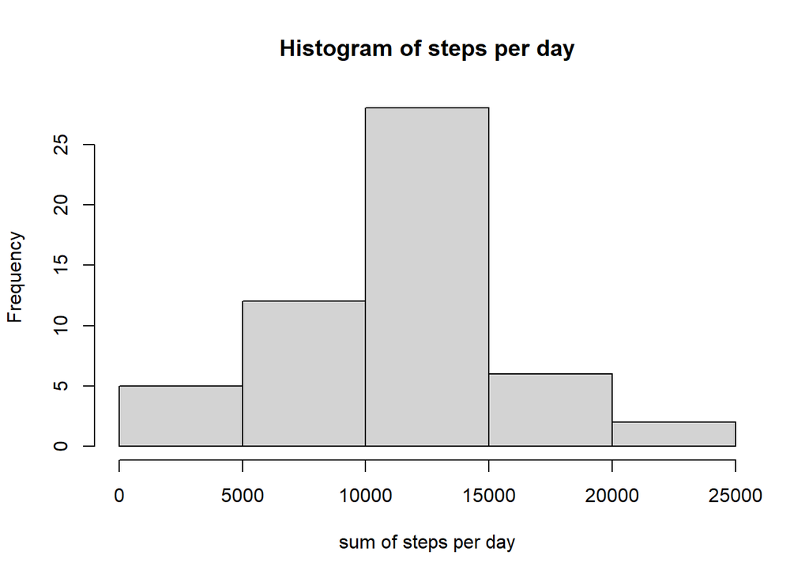

```r
steps <- activity.data %>%
        group_by(date) %>%
        summarise(sum_steps_per_day = sum(steps))

steps_per_day <- hist(steps$sum_steps_per_day, col = "lightgray", plot = TRUE,
                      xlab = "sum of steps per day",
                      main = "Histogram of steps per day")
```

```r
median_steps_per_day <- quantile(steps$sum_steps_per_day, probs = 0.5, na.rm = TRUE)
mean_steps_per_day <- mean(steps$sum_steps_per_day, na.rm = TRUE)
```

The count of steps taken per day appears to be normally distributed.  
The median of steps taken per day is 1.0765^{4}, the mean is 1.0766189^{4}.

## Analysis of daily activity pattern

The mean of steps taken at each interval was calculated and the result was plotted as time series.

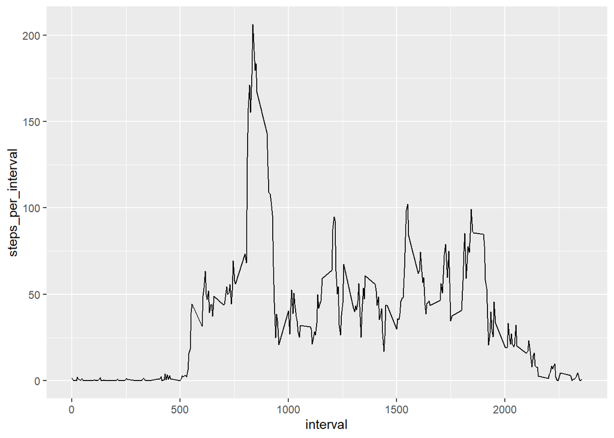

```r
intervals <- activity.data %>%
        group_by(interval) %>%
        summarise(steps_per_interval = mean(steps, na.rm = TRUE))
interval_plot <-
        ggplot(data = intervals, aes(x = interval, y = steps_per_interval)) +
        geom_line()
interval_plot
```

```r
max_steps <- max(intervals$steps_per_interval, na.rm = TRUE)
max_interval_dt <- intervals[intervals$steps_per_interval == max_steps, ]
max_interval <- unlist(max_interval_dt[1,1])
```

The average of steps taken per five minute interval fluctuates between 0 and 206.1698113. The interval with the highest average of steps is: 835

## Check for missing data

The data was visualized as heat map to check for missing data. Missing data is colored in grey.

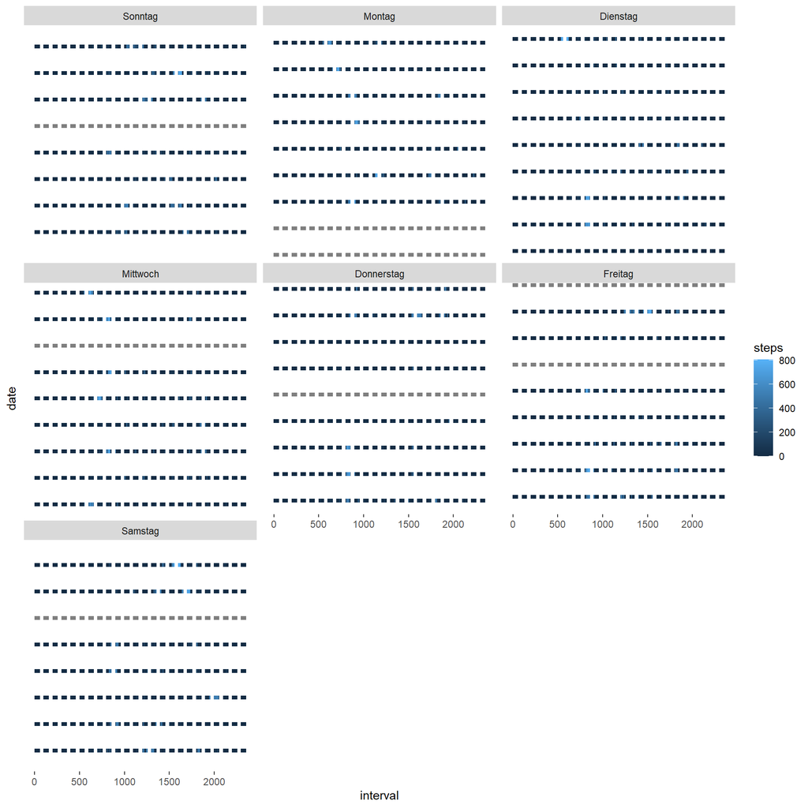

```r
plot_missing <-
        ggplot(data = activity.data, aes(x = interval, y = date, fill = steps)) +
        geom_tile() +
        theme(axis.text.y = element_blank(), axis.ticks.y = element_blank(),
              panel.background = element_rect(fill = "white", color = "white")) +
        facet_wrap(vars(weekday))
plot_missing
```

Data for eight whole days is missing from the dataset.Several weekdays are affected by missing data.

### Imputing missing values

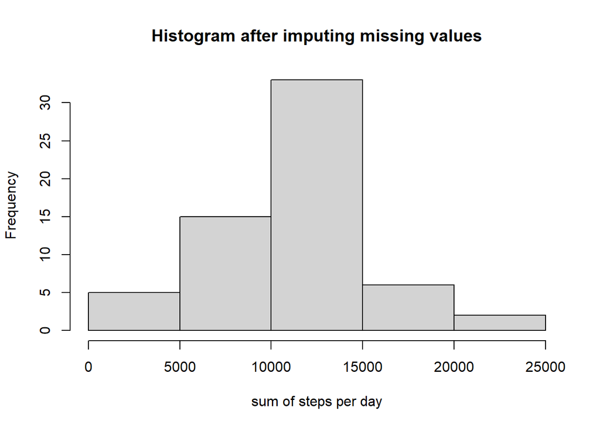

```r
weekday_vector <- unique(activity.data$weekday)
imputed_missing <- as.data.table(matrix(nrow =0, ncol = 4))
colnames(imputed_missing) <- names(activity.data)
for (i in weekday_vector) {
        temp_dt <- activity.data[weekday == i,]
        temp_dt[, steps:= ifelse(is.na(steps), mean(steps, na.rm = TRUE),steps),
                      by = interval]
        imputed_missing <- rbind(imputed_missing, temp_dt)
}
steps2 <- imputed_missing %>%
        group_by(date) %>%
        summarise(steps_per_day = sum(steps))

steps_per_day2 <- hist(steps2$steps_per_day, plot = TRUE,
                       xlab = "sum of steps per day",
                       main = "Histogram after imputing missing values")
```

```r
median_steps_per_day2 <- quantile(steps2$steps_per_day, probs = 0.5, na.rm = TRUE)
mean_steps_per_day2 <- mean(steps2$steps_per_day, na.rm = TRUE)
```

The count of steps taken per day appears to be normally distributed.  
The median of steps taken per day is 1.1015^{4}, the mean is 1.0809787^{4}. Distribution, mean and median of the dataset with imputed missing values are very close to the original dataset.

## Differences in activity patterns between weekdays and weekends

The calculation of mean steps per 5 minutes intervals was recalculated separately for weekdays and weekends.The dataset with filled-in missing values was used.

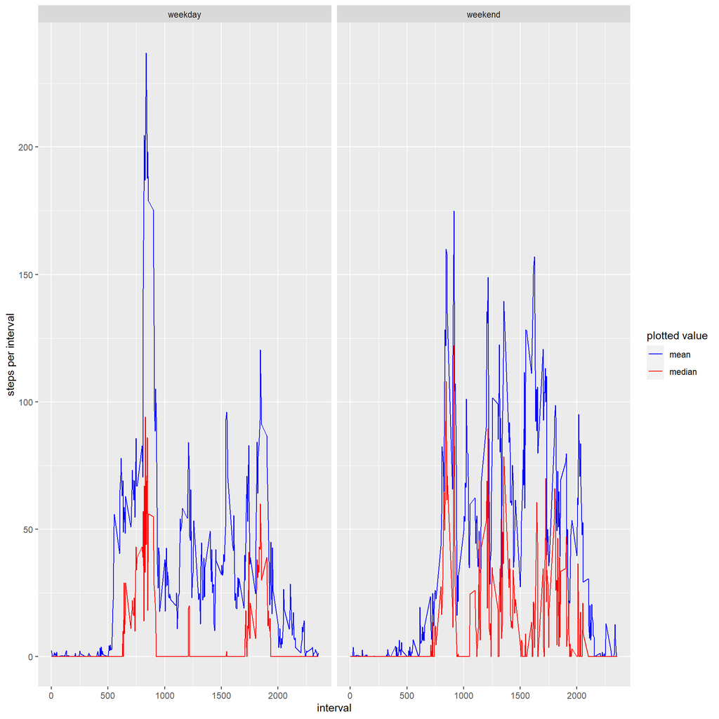

```r
imputed_missing$weekend <- imputed_missing$weekday
imputed_missing$weekend <- gsub("Sonntag", "weekend", imputed_missing$weekend)
imputed_missing$weekend <- gsub("Samstag", "weekend", imputed_missing$weekend)
imputed_missing$weekend <- gsub("Montag", "weekday", imputed_missing$weekend)
imputed_missing$weekend <- gsub("Dienstag", "weekday", imputed_missing$weekend)
imputed_missing$weekend <- gsub("Mittwoch", "weekday", imputed_missing$weekend)
imputed_missing$weekend <- gsub("Donnerstag", "weekday", imputed_missing$weekend)
imputed_missing$weekend <- gsub("Freitag", "weekday", imputed_missing$weekend)
weekend_summary <- imputed_missing %>%
        group_by(interval, weekend) %>%
        summarise(mean_steps_per_interval = mean(steps, na.rm = TRUE),
                  median_steps_per_interval = median(steps, na.rm = TRUE))
colors <- c("mean" = "blue", "median" = "red")

weekend_plot <-
        ggplot(data = weekend_summary) +
        geom_line(aes(x = interval, y = mean_steps_per_interval,
                      color = "mean")) +
        geom_line(aes(x = interval, y = median_steps_per_interval,
                      color = "median")) +
        labs(y = "steps per interval", color = "plotted value") +
        scale_color_manual(values = colors) +
        facet_wrap(vars(weekend))
weekend_plot
```